# Charlotte’s DE (mod’ed)

Nicolas Delhomme, mod’ed from Charlotte Soneson’s

2021-06-18

# 1 Setup

- Temp. fix

```r
options(connectionObserver = NULL)
```

- Libraries

```r
suppressPackageStartupMessages({
  library(DESeq2)
  library(edgeR)
  library(here)
  library(iSEE)
  library(org.Hs.eg.db)
  library(pheatmap)
  library(RColorBrewer)
  library(VennDiagram)
})
```

- Helpers

```r
source(here("UPSCb-common/src/R/volcanoPlot.R"))
```

- Graphics

```r
pal <- brewer.pal(8,"Dark2")
```

# 2 Differential Expression

## 2.1 DESeq2

Very easy, just one command

```r
ds_se <- DESeq2::DESeq(ds_se)
```

```
## using 'avgTxLength' from assays(dds), correcting for library size
```

### 2.1.1 Assessment

Here, we plot the dispersion estimation to ensure that the assumption that most genes are not differentially expressed holds

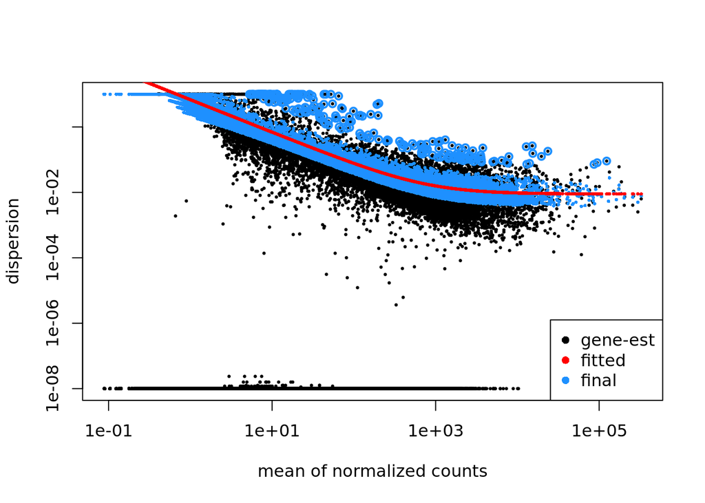

```r
DESeq2::plotDispEsts(ds_se)
```

### 2.1.2 Results

Here we extract the results

```r
res <- DESeq2::results(ds_se)
```

Wait! What was our design?

```r
design(ds_se)
```

```
## ~cell + dex
```

We have multiple possible contrast, which is the one R returns by default?

```r
colData(ds_se)[,c("dex","cell")]
```

```
## DataFrame with 8 rows and 2 columns
##                 dex     cell
##            <factor> <factor>
## SRR1039508    untrt  N61311
## SRR1039509    trt    N61311
## SRR1039512    untrt  N052611
## SRR1039513    trt    N052611
## SRR1039516    untrt  N080611
## SRR1039517    trt    N080611
## SRR1039520    untrt  N061011
## SRR1039521    trt    N061011
```

```r
levels(ds_se$dex)
```

```
## [1] "untrt" "trt"
```

```r
levels(ds_se$cell)
```

```
## [1] "N052611" "N061011" "N080611" "N61311"
```

By default the last on in the that list (which is sorted alphabetically)

```r
resultsNames(ds_se)
```

```
## [1] "Intercept"               "cell_N061011_vs_N052611"
## [3] "cell_N080611_vs_N052611" "cell_N61311_vs_N052611"
## [5] "dex_trt_vs_untrt"
```

So we are looking at the effect of treated vs untreated.

```r
head(res)
```

```
## log2 fold change (MLE): dex trt vs untrt
## Wald test p-value: dex trt vs untrt
## DataFrame with 6 rows and 6 columns
##                      baseMean log2FoldChange     lfcSE      stat      pvalue
##                     <numeric>      <numeric> <numeric> <numeric>   <numeric>
## ENSG00000000003.14 735.850024     -0.3662370  0.106108 -3.451560 0.000557355
## ENSG00000000005.5    0.000000             NA        NA        NA          NA
## ENSG00000000419.12 512.271228      0.2149097  0.126333  1.701130 0.088918582
## ENSG00000000457.13 310.647989      0.0251964  0.162138  0.155402 0.876504674
## ENSG00000000460.16  80.642808     -0.1369468  0.312082 -0.438816 0.660794596
## ENSG00000000938.12   0.310167     -1.3718532  3.503915 -0.391520 0.695412806
##                          padj
##                     <numeric>
## ENSG00000000003.14 0.00417173
## ENSG00000000005.5          NA
## ENSG00000000419.12 0.25077842
## ENSG00000000457.13 0.95409629
## ENSG00000000460.16 0.84566867
## ENSG00000000938.12         NA
```

OK, but what was my baseline?

```r
levels(ds_se$cell)
```

```
## [1] "N052611" "N061011" "N080611" "N61311"
```

Alright, we are looking at the effect of treated vs untreated in N052611

```r
mcols(res, use.names = TRUE)
```

```
## DataFrame with 6 rows and 2 columns
##                        type            description
##                 <character>            <character>
## baseMean       intermediate mean of normalized c..
## log2FoldChange      results log2 fold change (ML..
## lfcSE               results standard error: dex ..
## stat                results Wald statistic: dex ..
## pvalue              results Wald test p-value: d..
## padj                results   BH adjusted p-values
```

Let’s take a global look at the results

```r
summary(res)
```

```
##
## out of 35374 with nonzero total read count
## adjusted p-value < 0.1
## LFC > 0 (up)       : 2370, 6.7%
## LFC < 0 (down)     : 1965, 5.6%
## outliers [1]       : 0, 0%
## low counts [2]     : 18548, 52%
## (mean count < 8)
## [1] see 'cooksCutoff' argument of ?results
## [2] see 'independentFiltering' argument of ?results
```

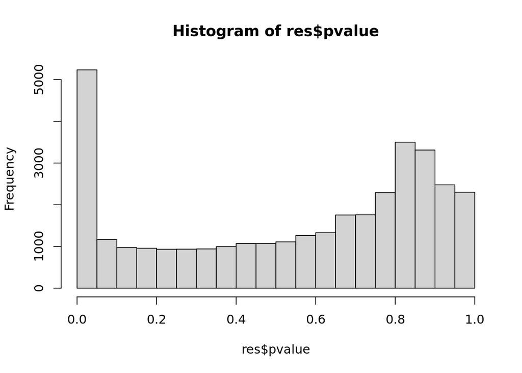

```r
hist(res$pvalue)
```

We add a couple of extra columns that will be useful for the interactive visualization later

```r
res$log10BaseMean <- log10(res$baseMean)
res$mlog10PValue <- -log10(res$pvalue)
rowData(ds_se)$log10Dispersion <- log10(rowData(ds_se)$dispersion)
rowData(ds_se)$DESeq2_dex_trt_vs_untrt <- res
```

### 2.1.3 Insights

#### 2.1.3.1 Changing the FDR

```r
res.05 <- results(ds_se, alpha = 0.05)
table(res.05$padj < 0.05)
```

```
##
## FALSE  TRUE
## 13272  3554
```

#### 2.1.3.2 Changing the log2FC - looking for a difference of expression of at least 1 fold change

```r
resLFC1 <- results(ds_se, lfcThreshold = 1)
summary(resLFC1)
```

```
##
## out of 35374 with nonzero total read count
## adjusted p-value < 0.1
## LFC > 1.00 (up)    : 136, 0.38%
## LFC < -1.00 (down) : 77, 0.22%
## outliers [1]       : 0, 0%
## low counts [2]     : 17223, 49%
## (mean count < 5)
## [1] see 'cooksCutoff' argument of ?results
## [2] see 'independentFiltering' argument of ?results
```

```r
table(resLFC1$padj < 0.1)
```

```
##
## FALSE  TRUE
## 17938   213
```

#### 2.1.3.3 Following Schurch et al., RNA, 2016 recommandations

```r
results(ds_se, lfcThreshold = 0.5, alpha=0.01)
```

```
## log2 fold change (MLE): dex trt vs untrt
## Wald test p-value: dex trt vs untrt
## DataFrame with 58294 rows and 6 columns
##                     baseMean log2FoldChange     lfcSE      stat    pvalue
##                    <numeric>      <numeric> <numeric> <numeric> <numeric>
## ENSG00000000003.14  735.8500     -0.3662370  0.106108         0         1
## ENSG00000000005.5     0.0000             NA        NA        NA        NA
## ENSG00000000419.12  512.2712      0.2149097  0.126333         0         1
## ENSG00000000457.13  310.6480      0.0251964  0.162138         0         1
## ENSG00000000460.16   80.6428     -0.1369468  0.312082         0         1
## ...                      ...            ...       ...       ...       ...
## ENSG00000285990.1    0.12412     -0.4749021  3.528022         0         1
## ENSG00000285991.1    9.24819     -0.0690465  0.780534         0         1
## ENSG00000285992.1    0.00000             NA        NA        NA        NA
## ENSG00000285993.1    0.00000             NA        NA        NA        NA
## ENSG00000285994.1    1.99136     -0.2486919  1.461267         0         1
##                         padj
##                    <numeric>
## ENSG00000000003.14         1
## ENSG00000000005.5         NA
## ENSG00000000419.12         1
## ENSG00000000457.13         1
## ENSG00000000460.16         1
## ...                      ...
## ENSG00000285990.1         NA
## ENSG00000285991.1          1
## ENSG00000285992.1         NA
## ENSG00000285993.1         NA
## ENSG00000285994.1         NA
```

### 2.1.4 Visualisation

#### 2.1.4.1 Assessment

A volcano plot (the naming is probably obvious) is very useful to check whether the assumption that most genes are not DE holds.

The plot has a representation of density as a color gradient from sparse to dense (gray -> blue -> red -> yellow). Note that the light blue, confusingly shows DE genes.

Here clearly most genes are located at 0,0 (the yellow dot)

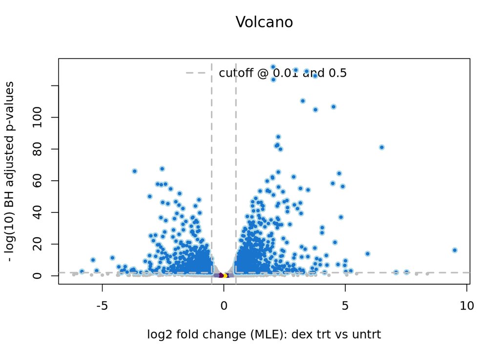

```r
volcanoPlot(res)
```

#### 2.1.4.2 individual genes

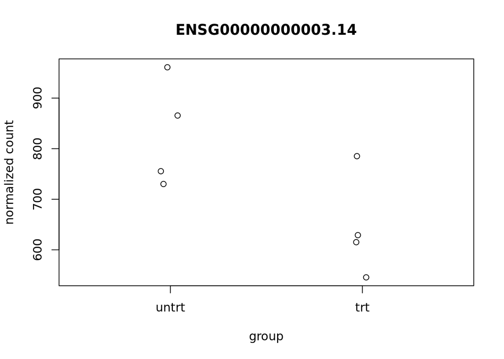

```r
plotCounts(ds_se, gene = "ENSG00000000003.14", intgroup = "dex",
           normalized = TRUE, transform = FALSE)
```

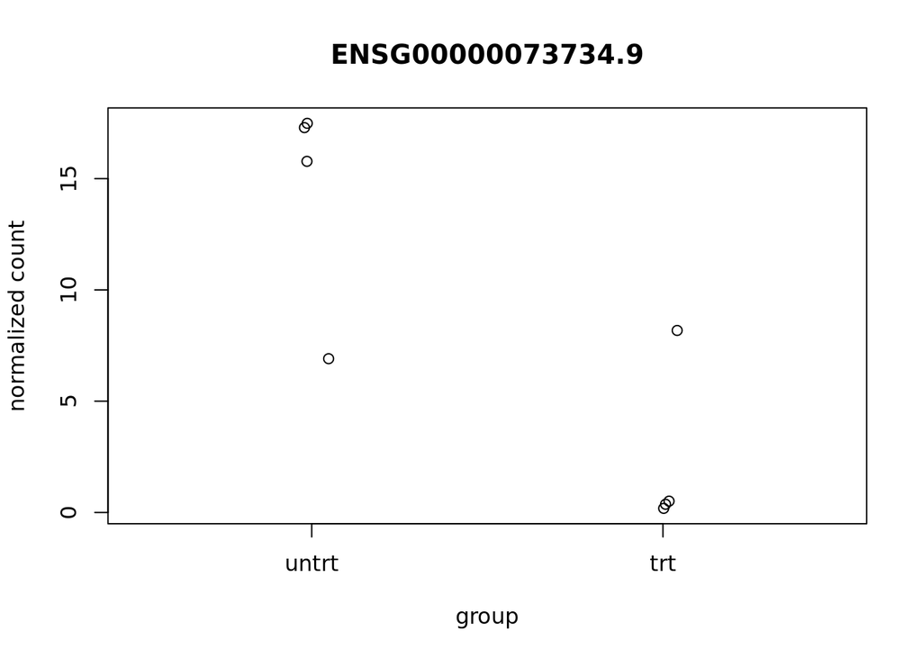

```r
plotCounts(ds_se, gene = "ENSG00000073734.9", intgroup = "dex",
           normalized = TRUE, transform = FALSE)
```

## 2.2 EdgeR

Let us define our model

```r
names(dge)
```

```
## [1] "counts"  "samples" "genes"   "offset"
```

```r
design <- model.matrix(~ cell + dex, data = dge$samples)
```

Perform the independent filtering (based on the model, filter the genes that have no power to be detected as differentially expressed. This aims at removing genes so lowly expressed that they represent “noise”)

```r
keep <- edgeR::filterByExpr(dge, design)
dge <- dge[keep, ]
```

Then we estimate the dispersion

```r
dge <- edgeR::estimateDisp(dge, design)
```

And we can take a look at the dispersion estimation (dispersion == biological coefficient of varation)

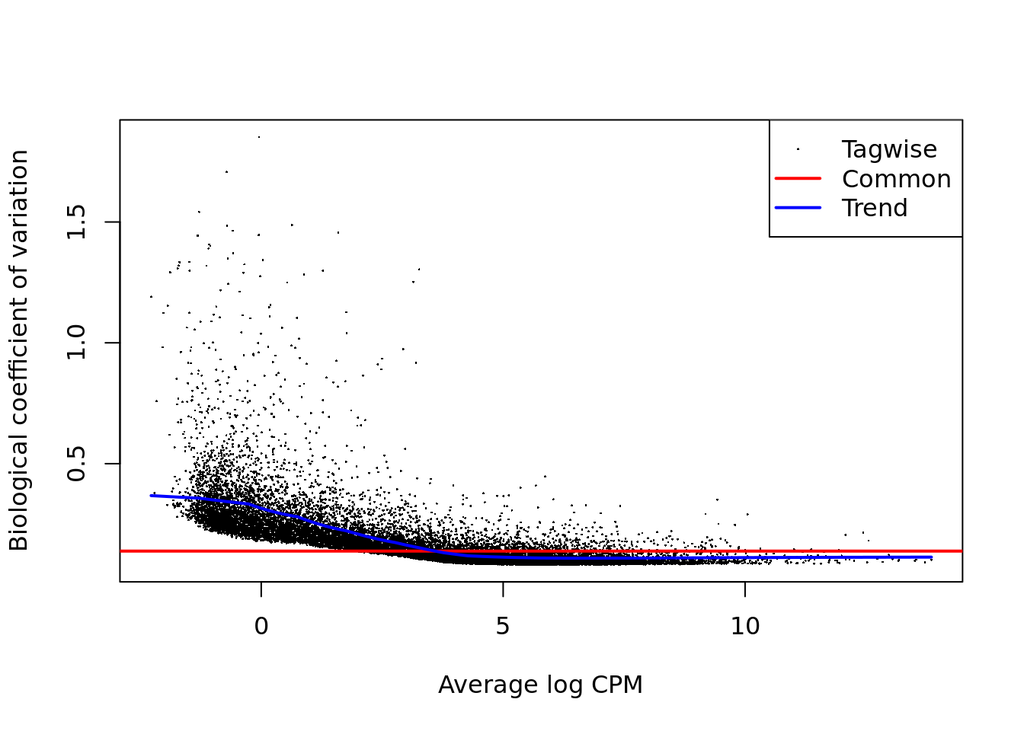

```r
edgeR::plotBCV(dge)
```

The, we can fit the model (using a quasi-likelihood f test)

```r
fit <- edgeR::glmQLFit(dge, design)
```

and test

```r
qlf <- edgeR::glmQLFTest(fit, coef = ncol(design))
```

Finally looking at the results

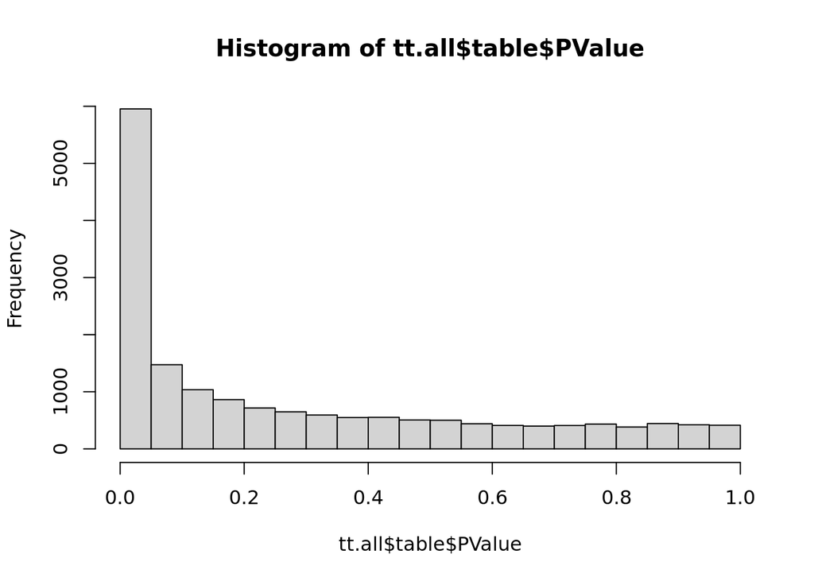

```r
tt.all <- edgeR::topTags(qlf, n = nrow(dge), sort.by = "none") # all genes
hist(tt.all$table$PValue)
```

```r
tt <- edgeR::topTags(qlf, n = nrow(dge), p.value = 0.1) # genes with adj.p<0.1
tt10 <- edgeR::topTags(qlf) # just the top 10 by default
tt10
```

```
## Coefficient:  dextrt
##                               gene.id     logFC   logCPM        F       PValue
## ENSG00000109906.13 ENSG00000109906.13  6.452722 4.091960 782.2426 9.518332e-09
## ENSG00000157214.13 ENSG00000157214.13  2.016403 7.072366 766.7199 1.024113e-08
## ENSG00000146250.6   ENSG00000146250.6 -2.731818 3.842446 764.4602 1.035210e-08
## ENSG00000162614.18 ENSG00000162614.18  2.027818 7.967856 707.3510 1.374386e-08
## ENSG00000120129.5   ENSG00000120129.5  2.948765 7.257634 654.2318 1.827130e-08
## ENSG00000189221.9   ENSG00000189221.9  3.391844 6.722830 609.0445 2.371690e-08
## ENSG00000126016.15 ENSG00000126016.15 -2.584790 4.126488 597.3944 2.544573e-08
## ENSG00000233117.2   ENSG00000233117.2  4.861912 1.793496 578.0816 2.868093e-08
## ENSG00000139132.14 ENSG00000139132.14  2.151165 5.768904 562.7905 3.162135e-08
## ENSG00000157150.4   ENSG00000157150.4  2.888764 3.124619 549.5924 3.447398e-08
##                             FDR
## ENSG00000109906.13 5.236736e-05
## ENSG00000157214.13 5.236736e-05
## ENSG00000146250.6  5.236736e-05
## ENSG00000162614.18 5.236736e-05
## ENSG00000120129.5  5.236736e-05
## ENSG00000189221.9  5.236736e-05
## ENSG00000126016.15 5.236736e-05
## ENSG00000233117.2  5.236736e-05
## ENSG00000139132.14 5.236736e-05
## ENSG00000157150.4  5.236736e-05
```

## 2.3 Comparison (DESeq2 as rows,edgeR as columns)

```r
shared <- intersect(rownames(res), tt.all$table$gene.id)
table(DESeq2 = res$padj[match(shared, rownames(res))] < 0.1,
      edgeR = tt.all$table$FDR[match(shared, tt.all$table$gene.id)] < 0.1)
```

```
##        edgeR
## DESeq2  FALSE  TRUE
##   FALSE 11609   787
##   TRUE    124  4206
```

including NAs to look at the independent filtering

```r
table(DESeq2 = res$padj[match(shared, rownames(res))] < 0.1,
      edgeR = tt.all$table$FDR[match(shared, tt.all$table$gene.id)] < 0.1,
      useNA="always")
```

```
##        edgeR
## DESeq2  FALSE  TRUE  <NA>
##   FALSE 11609   787     0
##   TRUE    124  4206     0
##   <NA>    370    54     0
```

let us do a visual comparison

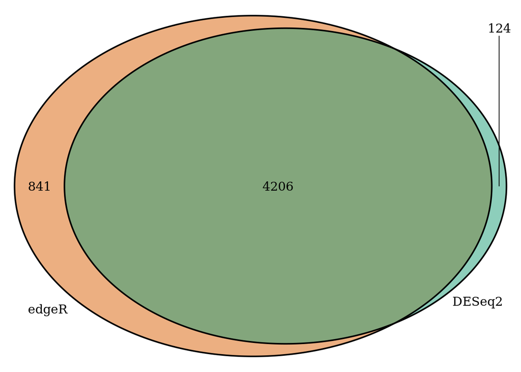

```r
grid.newpage()
d.sel <- match(shared, rownames(res))
e.sel <- match(shared, tt.all$table$gene.id)
grid.draw(venn.diagram(list(DESeq2 = rownames(res)[d.sel][res$padj[d.sel] < 0.1 & !is.na(res$padj[d.sel])],
                       edgeR = tt.all$table$gene.id[e.sel][tt.all$table$FDR[e.sel] < 0.1 & !is.na(tt.all$table$FDR[e.sel])]),
          NULL,fill=pal[1:2]))
```

edgeR seems a little more lenient than DESeq2

```r
sum(res$padj[match(shared, rownames(res))] < 0.1,na.rm = TRUE)
```

```
## [1] 4330
```

Looking at the differences in rank

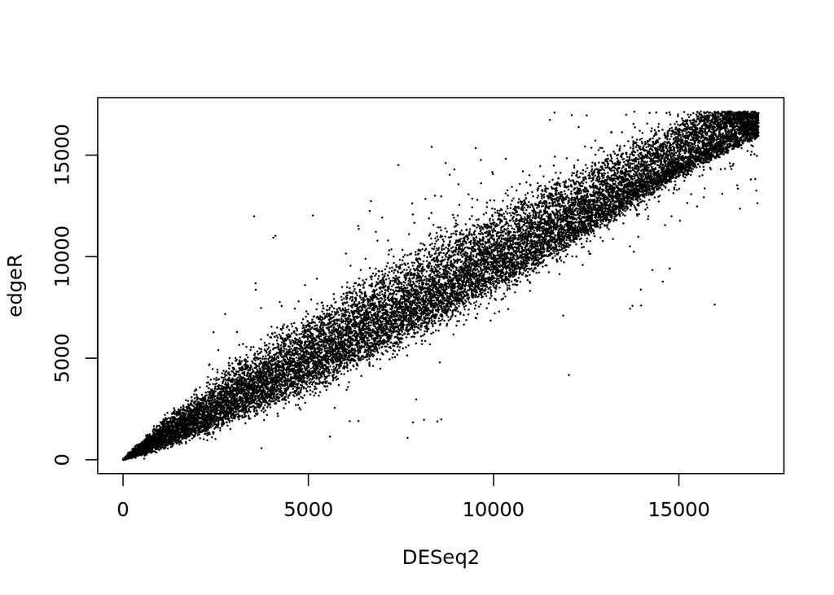

```r
plot(rank(res$pvalue[match(shared, rownames(res))]),
     rank(tt.all$table$PValue[match(shared, tt.all$table$gene.id)]),
     cex = 0.1, xlab = "DESeq2", ylab = "edgeR")
```

Same as for DESeq, looking for a more general hypothesis, lfc at least 1 or greater

```r
treatres <- edgeR::glmTreat(fit, coef = ncol(design), lfc = 1)
tt.treat <- edgeR::topTags(treatres, n = nrow(dge), sort.by = "none")
```

## 2.4 Another look at multiple testing

We have that many genes with a p.value below 0.05

```r
sum(res$pvalue < 0.05, na.rm = TRUE)
```

```
## [1] 5234
```

and that many genes not NA

```r
sum(!is.na(res$pvalue))
```

```
## [1] 35374
```

Assuming that there is no effect, we could expect that many genes

```r
round(sum(!is.na(res$pvalue)) * 0.05)
```

```
## [1] 1769
```

expected ratio of false positives in the set with p < .05

```r
round(sum(!is.na(res$pvalue))*0.05 / sum(res$pvalue < 0.05, na.rm = TRUE), 2)
```

```
## [1] 0.34
```

How many genes below 10% FDR

```r
sum(res$padj < 0.1, na.rm = TRUE)
```

```
## [1] 4335
```

## 2.5 Visualisation

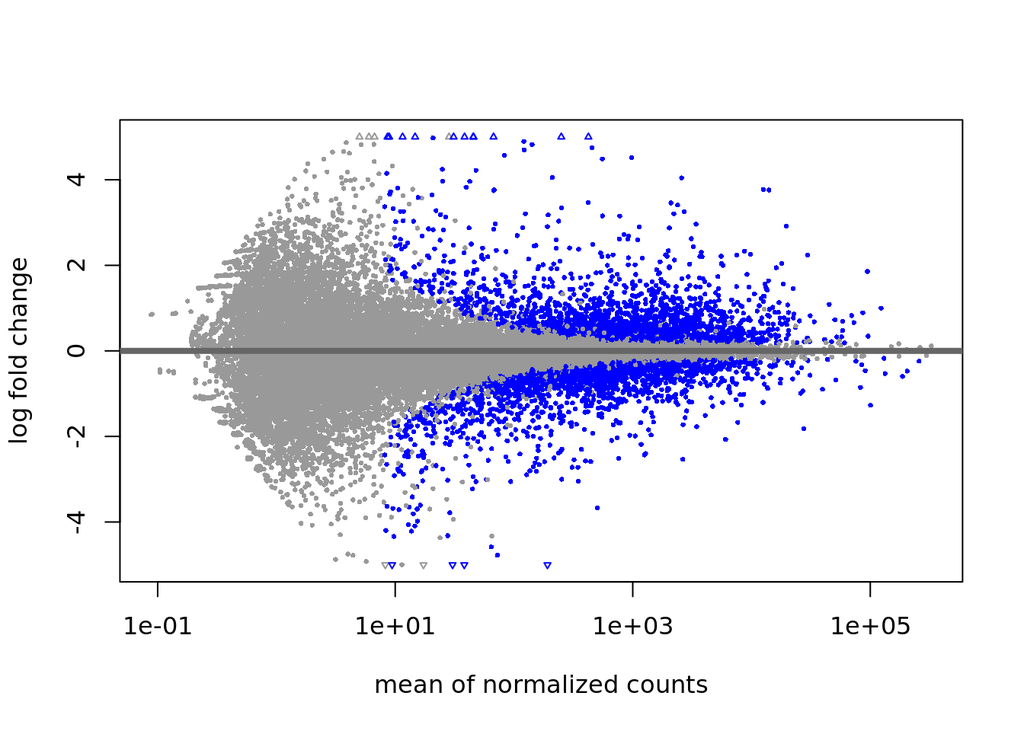

```r
DESeq2::plotMA(res, ylim = c(-5, 5))
```

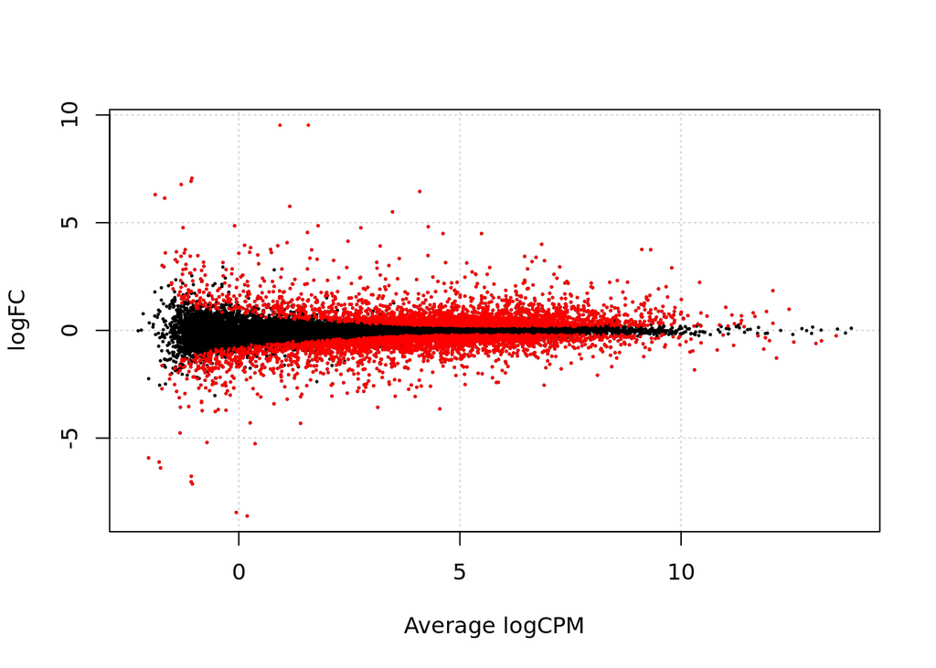

```r
edgeR::plotSmear(qlf, de.tags = tt$table$gene.id)
```

### 2.5.1 variance stabilising transformation

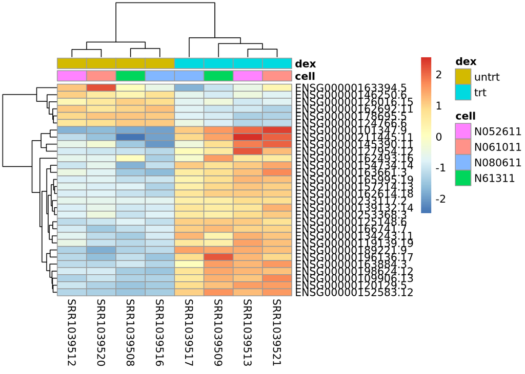

```r
vsd <- vst(ds_se,blind=FALSE)
mat <- assay(vsd)[head(order(res$padj), 30), ]
mat <- mat - rowMeans(mat)
df <- as.data.frame(colData(vsd)[, c("cell", "dex")])
pheatmap(mat, annotation_col = df)
```

## 2.6 Exporting the results

```r
res$symbol <- mapIds(org.Hs.eg.db,
                     keys = gsub("\\.[0-9]+$", "", row.names(res)),
                     column = "SYMBOL",
                     keytype = "ENSEMBL",
                     multiVals = "first")
resOrdered <- res[order(res$padj), ]
head(resOrdered)
```

```
## log2 fold change (MLE): dex trt vs untrt
## Wald test p-value: dex trt vs untrt
## DataFrame with 6 rows and 9 columns
##                     baseMean log2FoldChange     lfcSE      stat       pvalue
##                    <numeric>      <numeric> <numeric> <numeric>    <numeric>
## ENSG00000157214.13   3014.68        2.02984  0.081534   24.8956 8.30116e-137
## ENSG00000120129.5    3413.23        2.96254  0.120023   24.6832 1.62180e-134
## ENSG00000189221.9    2383.77        3.40906  0.138618   24.5931 1.49583e-133
## ENSG00000101347.9   14006.25        3.75916  0.154654   24.3070 1.65507e-130
## ENSG00000162614.18   5568.98        2.04110  0.084779   24.0755 4.51561e-128
## ENSG00000196136.17   2709.08        3.25099  0.142910   22.7485 1.48345e-114
##                            padj log10BaseMean mlog10PValue      symbol
##                       <numeric>     <numeric>    <numeric> <character>
## ENSG00000157214.13 1.39675e-132       3.47924      136.081      STEAP2
## ENSG00000120129.5  1.36442e-130       3.53317      133.790       DUSP1
## ENSG00000189221.9  8.38960e-130       3.37726      132.825        MAOA
## ENSG00000101347.9  6.96207e-127       4.14632      129.781      SAMHD1
## ENSG00000162614.18 1.51959e-124       3.74578      127.345        NEXN
## ENSG00000196136.17 4.16008e-111       3.43282      113.829    SERPINA3
```

```r
resOrderedDF <- as.data.frame(resOrdered)[seq_len(100), ]
write.table(cbind(id = rownames(resOrderedDF), resOrderedDF),
            file = here("analysis/DE/results.txt"), quote = FALSE, sep = "\t",
            row.names = FALSE)
```